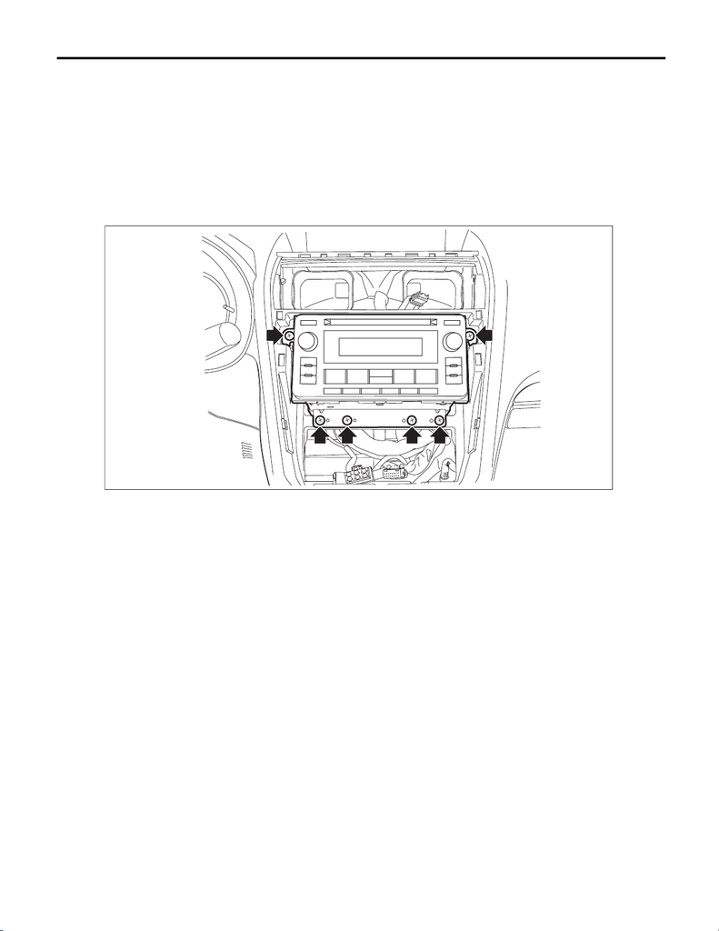

Audio

ENTERTAINMENT

5. Audio

A: REMOVAL

1) Disconnect the ground cable from battery. <Ref. to NT-5, BATTERY, NOTE, Note.>

NOTE:

For models other than STI model, disconnect the ground terminal from battery sensor.

2) Remove the panel center assembly. <Ref. to EI-66, REMOVAL, Center Console.>

3) Remove the audio assembly.

(1) Remove the screws, and partially pull out the audio assembly.

(2) Disconnect the connectors, and remove the audio assembly.

B: INSTALLATION

CAUTION:

After installing the panel center assembly, check that the air vent grille of the panel center assembly

is inserted correctly into the air vent duct.

1) Install the audio assembly.

2) Install the panel center assembly.

3) Connect the battery ground terminal. <Ref. to NT-5, BATTERY, NOTE, Note.>

NOTE:

For models other than STI model, connect the ground terminal to battery sensor.